# Ejercicio Regresión 2

Julio Sorroche García

12 de enero de 2018

## Modelos

En este ejercicio vamos a comparar distintos modelos realizados a partir del conjunto de datos *ToyotaCorolla*.

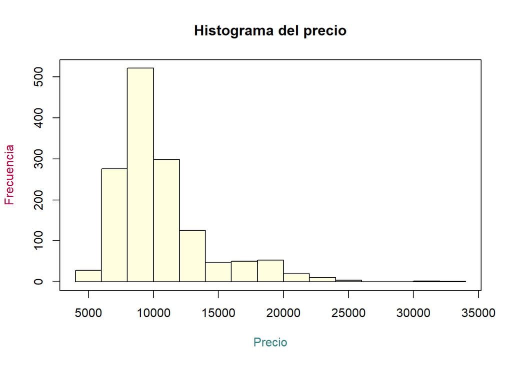

En este caso vamos a fijarnos en el precio, el cual oscila en un rango de **4350-32500**$, nuestro objetivo tratará en averiguar de qué depende este, o al menos si alguno de los atributos de los coches disponibles tiene algo en relación.

Para obtener unos modelos interesantes, primero se escogerán los coeficientes más estadísticamente relevantes. En este caso se ha decidido comparar el **precio** de los Toyota con el resto de sus características, en un intento de averiguar con qué está relacionado el precio.

```
##
## Call:
## lm(formula = Price ~ ., data = Toyodata)
##
## Residuals:
##      Min       1Q   Median       3Q      Max
## -10642.3   -737.7      3.1    731.3   6451.5
##
## Coefficients:
##                  Estimate Std. Error t value Pr(>|t|)
## (Intercept)    -3.801e+03  1.304e+03  -2.915 0.003613 **
## Age            -1.220e+02  2.602e+00 -46.889  < 2e-16 ***
## KM             -1.621e-02  1.313e-03 -12.347  < 2e-16 ***
## FuelTypeDiesel  3.390e+03  5.188e+02   6.535 8.86e-11 ***
## FuelTypePetrol  1.121e+03  3.324e+02   3.372 0.000767 ***
## HP              6.081e+01  5.756e+00  10.565  < 2e-16 ***
## MetColor        5.716e+01  7.494e+01   0.763 0.445738
## Automatic       3.303e+02  1.571e+02   2.102 0.035708 *
## CC             -4.174e+00  5.453e-01  -7.656 3.53e-14 ***
## Doors          -7.776e+00  4.006e+01  -0.194 0.846129
## Weight          2.001e+01  1.203e+00  16.629  < 2e-16 ***
## ---
## Signif. codes:  0 '***' 0.001 '**' 0.01 '*' 0.05 '.' 0.1 ' ' 1
##
## Residual standard error: 1316 on 1425 degrees of freedom
## Multiple R-squared:  0.8693, Adjusted R-squared:  0.8684
## F-statistic:   948 on 10 and 1425 DF,  p-value: < 2.2e-16
```

Tanto el **peso** (*weight*) como la **edad** (*age*) son las más dependientes respecto al **precio** (*price*), esto es sabido por su elevado valor del **t-value** tanto en el primer *(-46.889)* como en el segundo caso *(16.629)*, independientemente del signo. Estos coeficientes serán los que utilizaremos en los modelos para evaluar cual es el más preciso .

### Modelo 1

Comenzamos con el primer Modelo que se trata simplemente de una regresión lineal de la **edad** sobre el **precio**.

```
##
## Call:
## lm(formula = Price ~ Age, data = Toyodata)
##
## Residuals:
##     Min      1Q  Median      3Q     Max
## -8423.0  -997.4   -24.6   878.5 12889.7
##
## Coefficients:
##              Estimate Std. Error t value Pr(>|t|)
## (Intercept) 20294.059    146.097  138.91   <2e-16 ***
## Age          -170.934      2.478  -68.98   <2e-16 ***
## ---
## Signif. codes:  0 '***' 0.001 '**' 0.01 '*' 0.05 '.' 0.1 ' ' 1
##
## Residual standard error: 1746 on 1434 degrees of freedom
## Multiple R-squared:  0.7684, Adjusted R-squared:  0.7682
## F-statistic:  4758 on 1 and 1434 DF,  p-value: < 2.2e-16
```

El coeficiente principal es **-170** en primer grado, por tanto la fórmula del modelo es: **$2.0295\times 10^{4}+-170x$**

Como modelo se podría decir que es decentemente preciso, dado que su $R^{2}$ es del **76.84**%, sin embargo su p-value es bastante pequeño lo cual indica una buena aproximación.

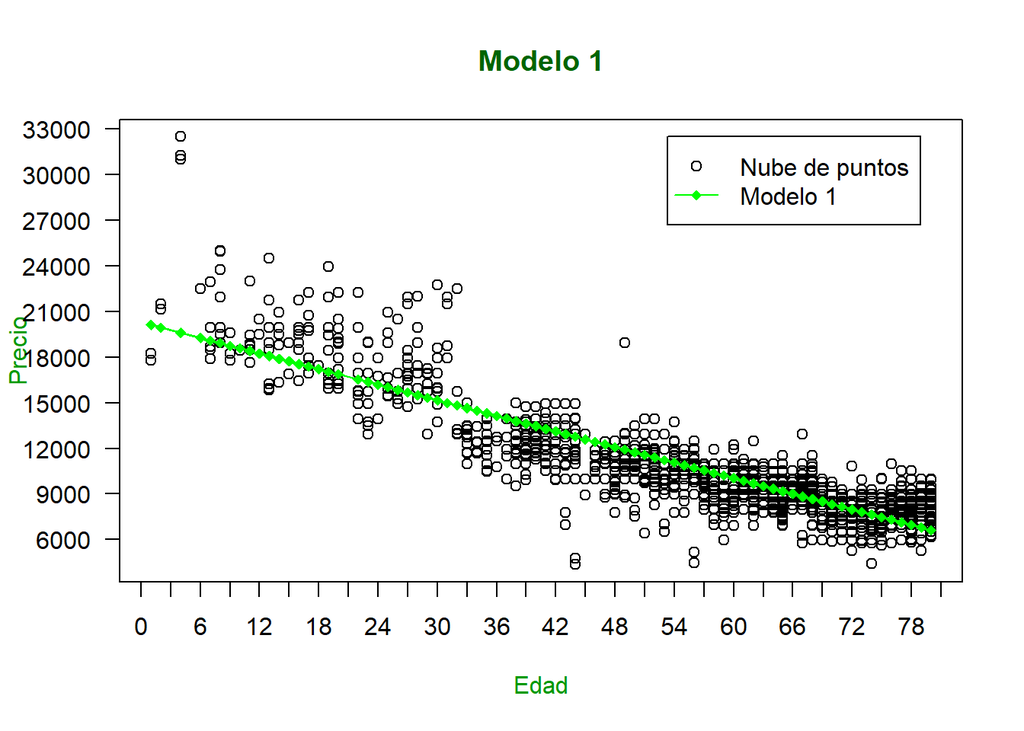

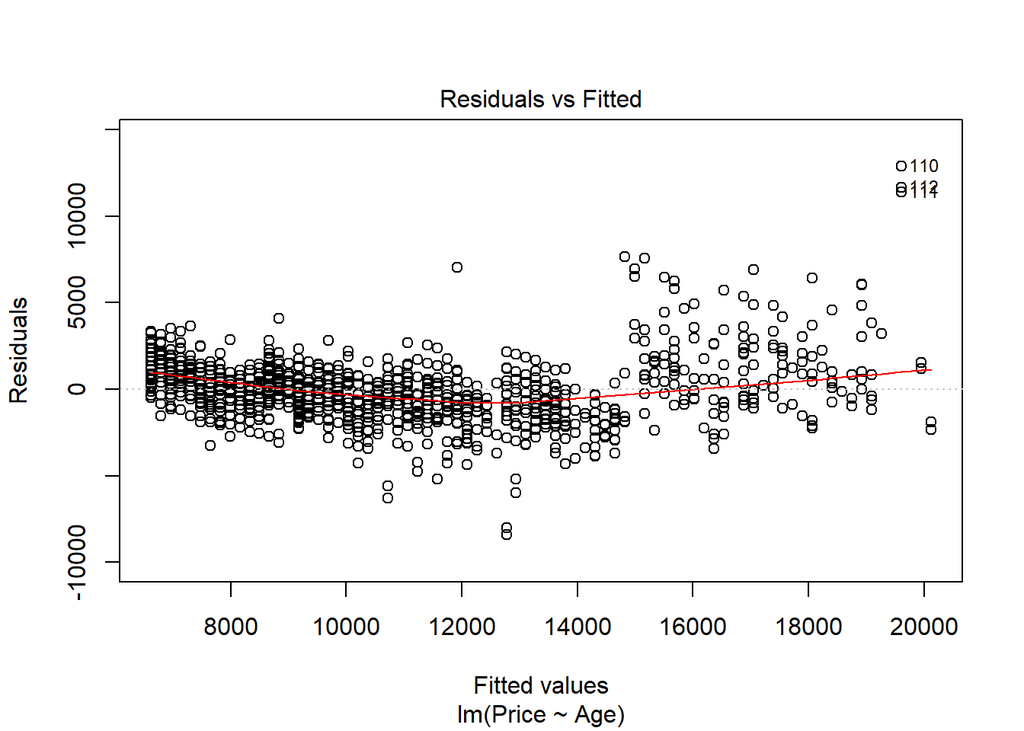

### Modelo 2

Para apreciar las diferencias entre ambos coeficientes, se ha decidido utilizar el **peso<sup>2</sup>** con polinomios ortogonales para el segundo modelo sobre el **precio**.

```
##
## Call:
## lm(formula = Price ~ poly(Weight, 2), data = Toyodata)
##
## Residuals:
##      Min       1Q   Median       3Q      Max
## -14291.3  -1782.7   -134.3   1619.7  11156.3
##
## Coefficients:
##                   Estimate Std. Error t value Pr(>|t|)
## (Intercept)       10730.82      77.45  138.54  < 2e-16 ***
## poly(Weight, 2)1  79853.34    2935.10   27.21  < 2e-16 ***
## poly(Weight, 2)2 -12475.45    2935.10   -4.25 2.27e-05 ***
## ---
## Signif. codes:  0 '***' 0.001 '**' 0.01 '*' 0.05 '.' 0.1 ' ' 1
##
## Residual standard error: 2935 on 1433 degrees of freedom
## Multiple R-squared:  0.346,  Adjusted R-squared:  0.3451
## F-statistic: 379.1 on 2 and 1433 DF,  p-value: < 2.2e-16
```

El coeficiente principal es **-1.247510^{4}** en segundo grado, por tanto la fórmula del modelo es: **$1.0731\times 10^{4}+7.9854\times 10^{4}x+-1.2475\times 10^{4}x^{2}$**

Como modelo es muy impreciso, con su $R^{2}$ del **34.6**%, sin embargo su p-value es idéntico al anterior. Aún así debido a su precisión no es el modelo adecuado a escoger.

[figure not shown]

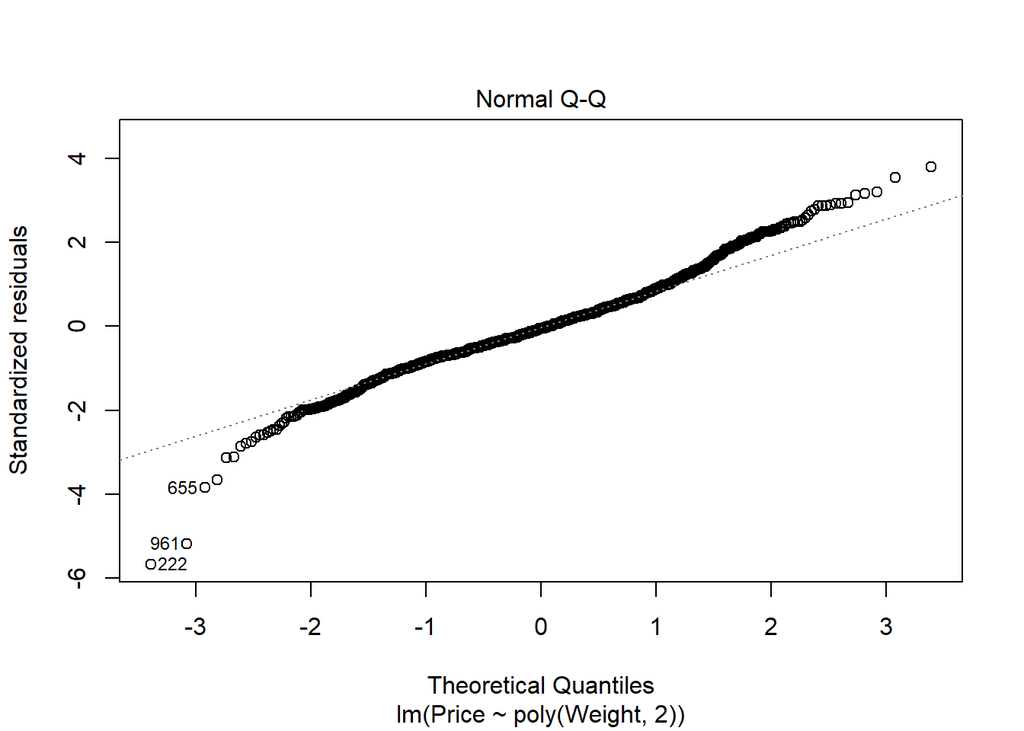

### Modelo 3

Tras entender la poca utilidad del coeficiente **peso** en solitario, se usará de nuevo la **edad**, esta vez al *cubo*. A ella se le unirá el **peso** como apoyo.

```
##
## Call:
## lm(formula = Price ~ poly(Age, 3) + Weight, data = Toyodata)
##
## Residuals:
##     Min      1Q  Median      3Q     Max
## -8013.8  -779.9    31.6   843.6  7443.5
##
## Coefficients:
##                 Estimate Std. Error t value Pr(>|t|)
## (Intercept)   -1.253e+03  9.391e+02  -1.334    0.182
## poly(Age, 3)1 -1.100e+05  1.693e+03 -64.962   <2e-16 ***
## poly(Age, 3)2  2.422e+04  1.540e+03  15.732   <2e-16 ***
## poly(Age, 3)3 -5.874e+02  1.481e+03  -0.397    0.692
## Weight         1.117e+01  8.749e-01  12.771   <2e-16 ***
## ---
## Signif. codes:  0 '***' 0.001 '**' 0.01 '*' 0.05 '.' 0.1 ' ' 1
##
## Residual standard error: 1481 on 1431 degrees of freedom
## Multiple R-squared:  0.8338, Adjusted R-squared:  0.8334
## F-statistic:  1795 on 4 and 1431 DF,  p-value: < 2.2e-16
```

El coeficiente principal es **-587** en tercer grado, por tanto la fórmula del modelo es: **$12+-1252+-1.0996\times 10^{5}x+2.4222\times 10^{4}x^{2}+-587x^{3}$**

Como modelo supera en precisión a los dos anteriores, siendo su $R^{2}$ del **83.38**%, el p-value no sufre cambios, es por ahora el modelo más idóneo.

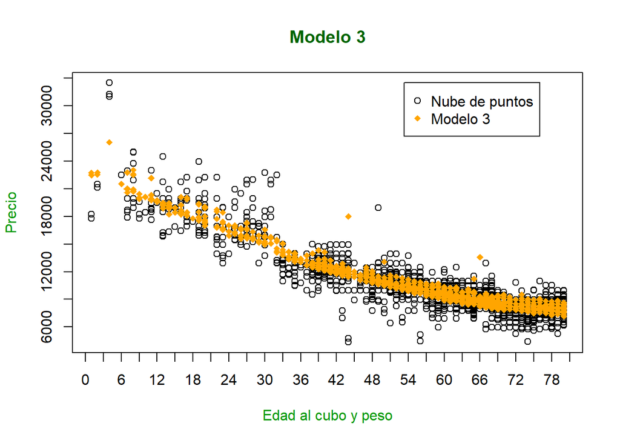

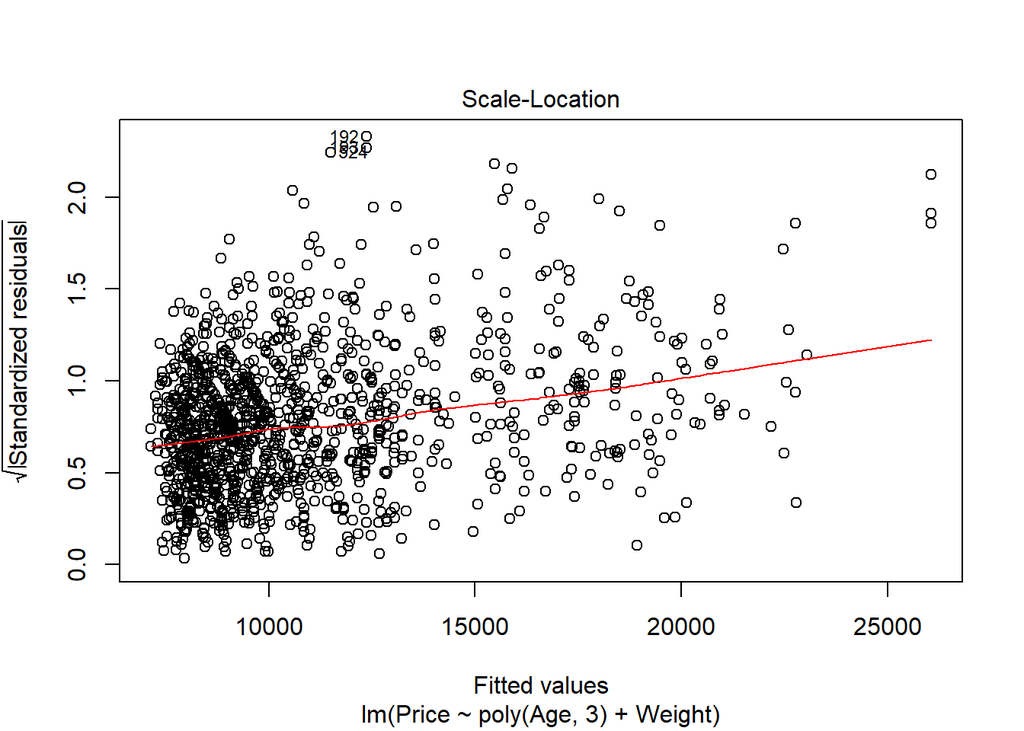

### Modelo 4

De nuevo por ofrecer una diferencia, se expondrá la **edad<sup>3</sup>** respecto al precio. Esta vez los polinomios no tendrán por qué ser ortogonales.

```
##
## Call:
## lm(formula = Price ~ poly(Age, 3, raw = TRUE), data = Toyodata)
##
## Residuals:
##     Min      1Q  Median      3Q     Max
## -7631.8  -834.7   -24.3   848.9  9680.1
##
## Coefficients:
##                             Estimate Std. Error t value Pr(>|t|)
## (Intercept)                2.428e+04  3.892e+02  62.398  < 2e-16 ***
## poly(Age, 3, raw = TRUE)1 -3.745e+02  3.132e+01 -11.955  < 2e-16 ***
## poly(Age, 3, raw = TRUE)2  2.216e+00  7.425e-01   2.984  0.00289 **
## poly(Age, 3, raw = TRUE)3 -1.321e-03  5.298e-03  -0.249  0.80313
## ---
## Signif. codes:  0 '***' 0.001 '**' 0.01 '*' 0.05 '.' 0.1 ' ' 1
##
## Residual standard error: 1562 on 1432 degrees of freedom
## Multiple R-squared:  0.8149, Adjusted R-squared:  0.8145
## F-statistic:  2101 on 3 and 1432 DF,  p-value: < 2.2e-16
```

Su precisión es normal respecto a la anterior, aunque no superior con un **81.49**%. Es evidente que el p-value no va a cambiar y es necesario por tanto buscar el modelo más preciso.

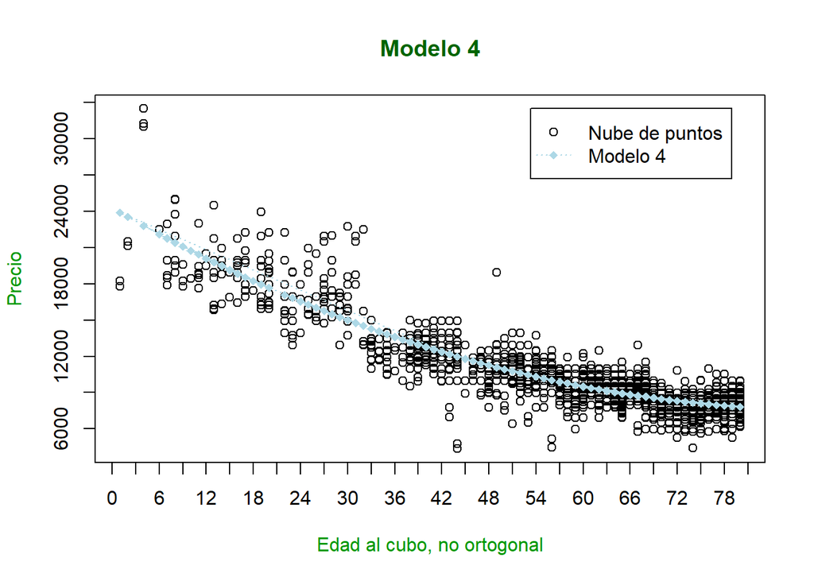

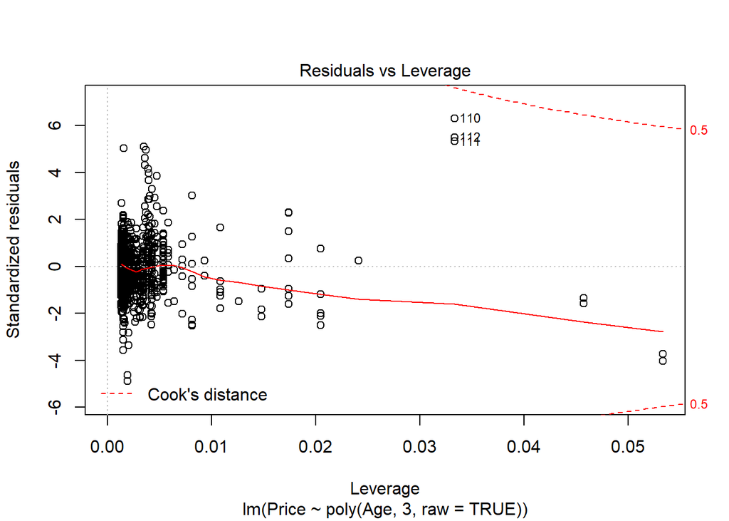

### Modelo 5

Después de estos intentos, parece que no es posible mejorar el modelo aumentando el exponente del polinomio, por eso se añade el tercer coeficiente más relevante a la fórmula, los *KM*. Junto con el **peso** y la **edad<sup>2</sup>** se busca alcanzar el modelo más preciso.

```
##
## Call:
## lm(formula = Price ~ poly(Age, 2) + Weight + KM, data = Toyodata)
##
## Residuals:
##     Min      1Q  Median      3Q     Max
## -7910.5  -732.9    -0.7   713.1  6958.5
##
## Coefficients:
##                 Estimate Std. Error t value Pr(>|t|)
## (Intercept)   -4.904e+03  8.613e+02  -5.694  1.5e-08 ***
## poly(Age, 2)1 -8.997e+04  1.844e+03 -48.794  < 2e-16 ***
## poly(Age, 2)2  2.001e+04  1.394e+03  14.356  < 2e-16 ***
## Weight         1.596e+01  8.217e-01  19.420  < 2e-16 ***
## KM            -2.158e-02  1.137e-03 -18.976  < 2e-16 ***
## ---
## Signif. codes:  0 '***' 0.001 '**' 0.01 '*' 0.05 '.' 0.1 ' ' 1
##
## Residual standard error: 1323 on 1431 degrees of freedom
## Multiple R-squared:  0.8672, Adjusted R-squared:  0.8669
## F-statistic:  2337 on 4 and 1431 DF,  p-value: < 2.2e-16
```

El coeficiente principal es **2.001310^{4}** en segundo grado, por tanto la fórmula del modelo es: **$-4903+16+0+-8.9967\times 10^{4}x+2.0013\times 10^{4}x^{2}$**

Su precisión es la mayor conseguida hasta ahora, con un acierto del **86.72**%. Esto es debido al nuevo coeficiente agregado y la utilización prudente de polinomios ortogonales.

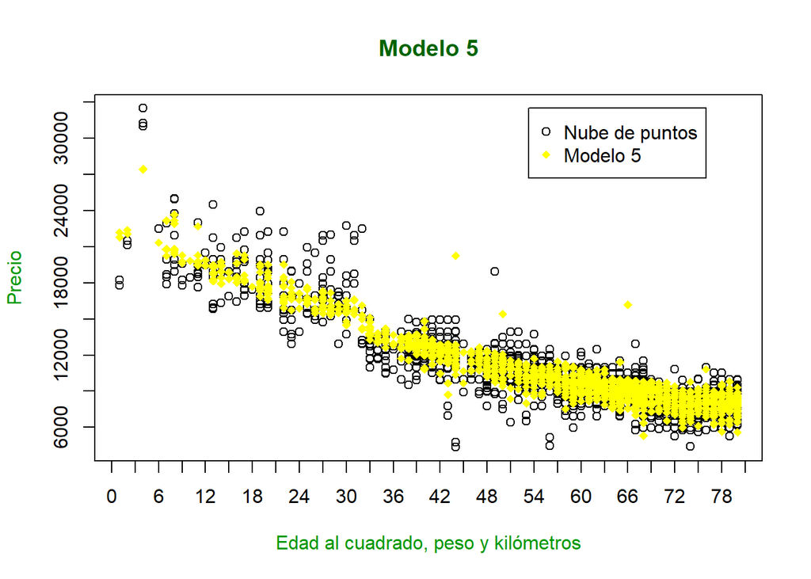

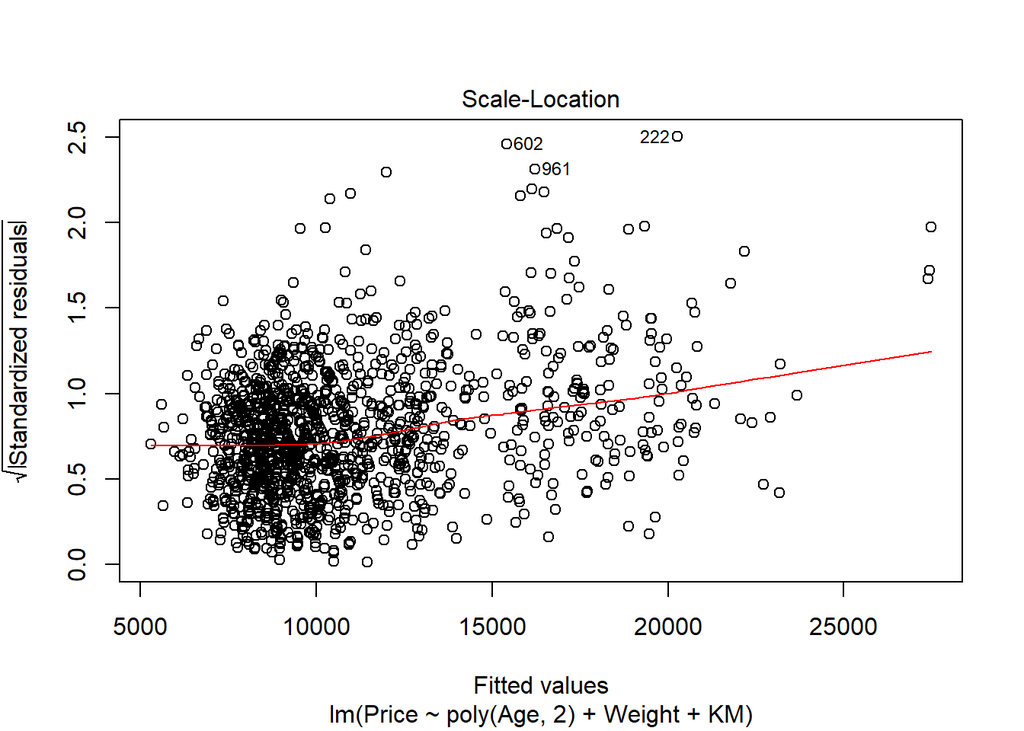

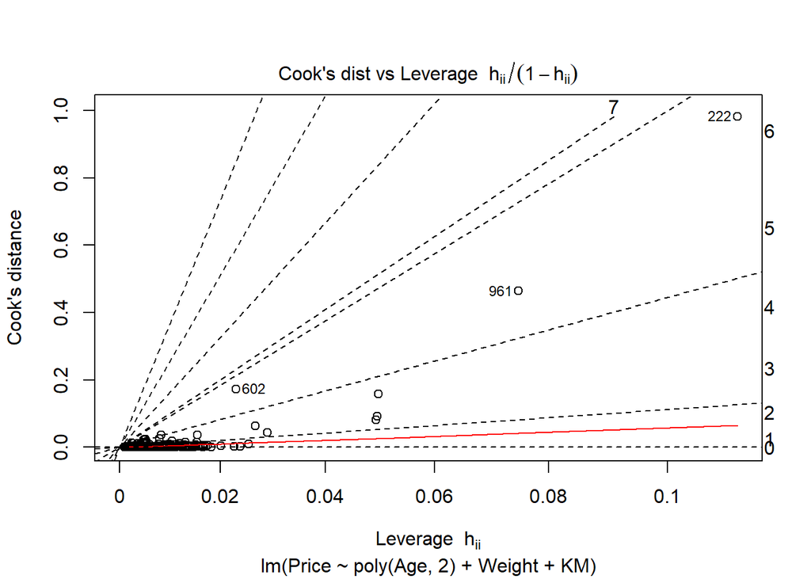

### Comparación de modelos mediante ANOVA

```r
anova(mod1,mod2,mod3,mod4,mod5)
```

```
## Analysis of Variance Table
##
## Model 1: Price ~ Age
## Model 2: Price ~ poly(Weight, 2)
## Model 3: Price ~ poly(Age, 3) + Weight
## Model 4: Price ~ poly(Age, 3, raw = TRUE)
## Model 5: Price ~ poly(Age, 2) + Weight + KM
##   Res.Df        RSS Df   Sum of Sq       F    Pr(>F)
## 1   1434 4.3718e+09
## 2   1433 1.2345e+10  1 -7973285786
## 3   1431 3.1368e+09  2  9208253512 2100.39 < 2.2e-16 ***
## 4   1432 3.4943e+09 -1  -357540176  163.11 < 2.2e-16 ***
## 5   1431 2.5064e+09  1   987919421  450.69 < 2.2e-16 ***
## ---
## Signif. codes:  0 '***' 0.001 '**' 0.01 '*' 0.05 '.' 0.1 ' ' 1
```